[Antonio Schettino](https://asch3tti.netlify.com/)

January 15th, 2020

# Exercise 1

Install and load the `tidyverse`.

```r
install.packages("tidyverse")
library(tidyverse)
```

# Exercise 2

## Exercise 2.1

Do the following operations **in one go**:

- load the original data (`MixedAttitude.dat`)
- convert `sex` to a **categorical** variable (named `gender`) with 2 levels:
  - 1 –> female
  - 2 –> male
- eliminate from the data set the following variables: `sex`, `beerpos`, `beerneg`, `beerneut`, `winepos`, and `waterpos`
- using the function `rename`, rename the variables you kept:
  - ssj –> participant
  - wineneg –> wine_negative
  - wineneut –> wine_neutral
  - waterneg –> water_negative
  - waterneu –> water_neutral
- filter out outlier participants as well as all participants who rated *water* after *neutral* imagery as **lower than -10**
- convert the data set to **long** format
- separate conditions into 2 variables (`drink` and `imagery`)
- convert `participant`, `gender`, `drink`, and `imagery` to factors

When you have completed these operations, save the data set as `data_attitude_wine.csv` in the subfolder `tidy-data`.

```r
library(here)
library(tidyverse)

data_attitude_wine <-
  read_csv(
    here(
      "raw-data",
      "MixedAttitude.dat"
    )
  ) %>%
  mutate(
    gender = recode(
      factor(sex),
      "1" = "female", "2" = "male"
    )
  ) %>%
  select(-c(
    sex,
    beerpos,
    beerneg,
    beerneut,
    winepos,
    waterpos
  )) %>%
  rename(
    participant = ssj,
    wine_negative = wineneg,
    wine_neutral = wineneut,
    water_negative = waterneg,
    water_neutral = waterneu
  ) %>%
  filter(
    water_neutral >= -100 & water_neutral <= +100 &
      water_neutral >= -10
  ) %>%
  pivot_longer(
    cols = c(wine_negative, wine_neutral, water_negative, water_neutral),
    names_to = "condition",
    values_to = "ratings",
  ) %>%
  separate(
    condition, c("drink", "imagery"),
    remove = TRUE
  ) %>%
  mutate(
    participant = as_factor(participant),
    gender = as_factor(gender),
    drink = as_factor(drink),
    imagery = as_factor(imagery)
  )

write_csv(
  data_attitude_wine,
  here("tidy-data", "data_attitude_wine.csv")
)
```

## Exercise 2.2

Using the output of **Exercise 2.1**:

- separately for `gender`, `drink`, and `imagery`, calculate the following summary statistics:
  - number of observations
  - median
  - median absolute deviation
  - minimum value
  - maximum value
- display the results in console

```r
summary_data_attitude_wine <-
  data_attitude_wine %>%
  group_by(gender, drink, imagery) %>%
  summarize(
    n = n(),
    median = median(ratings),
    mad = mad(ratings),
    min = min(ratings),
    max = max(ratings)
  ) %>%
  ungroup() %>%
  print()
```

```
## # A tibble: 8 x 8
##   gender drink imagery      n median   mad   min   max
##   <fct>  <fct> <fct>    <int>  <dbl> <dbl> <dbl> <dbl>
## 1 female wine  negative     8   -6    5.93   -15    -2
## 2 female wine  neutral      8    6.5  5.93     0    16
## 3 female water negative     8  -11    5.93   -20     5
## 4 female water neutral      8    1.5  2.22    -5     4
## 5 male   wine  negative    10  -15.5  2.97   -23    -9
## 6 male   wine  neutral     10   16.5  4.45     7    21
## 7 male   water negative    10   -7    8.15   -19    -1
## 8 male   water neutral     10    8    3.71     0    12
```

# Exercise 3

## Exercise 3.0

Load `data_attitude_wine.csv`.

```r
data_attitude_wine <-
  read_csv(
    here(
      "tidy-data",
      "data_attitude_wine.csv"
    )
  )
```

## Exercise 3.1

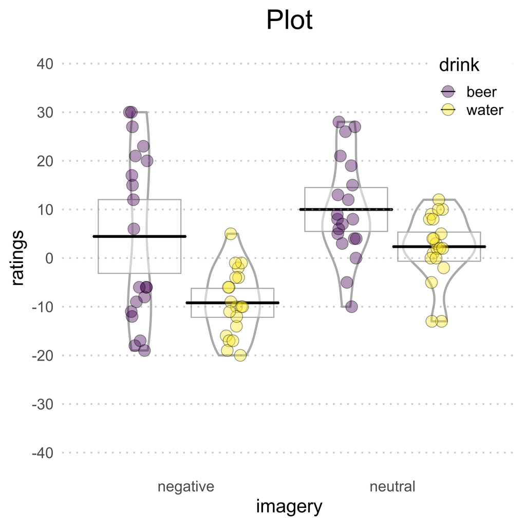

*RDI plot generated during the workshop.*

Create a plot similar to what is shown above (with `wine` instead of `beer`) and save it in the subfolder `doc/images`.

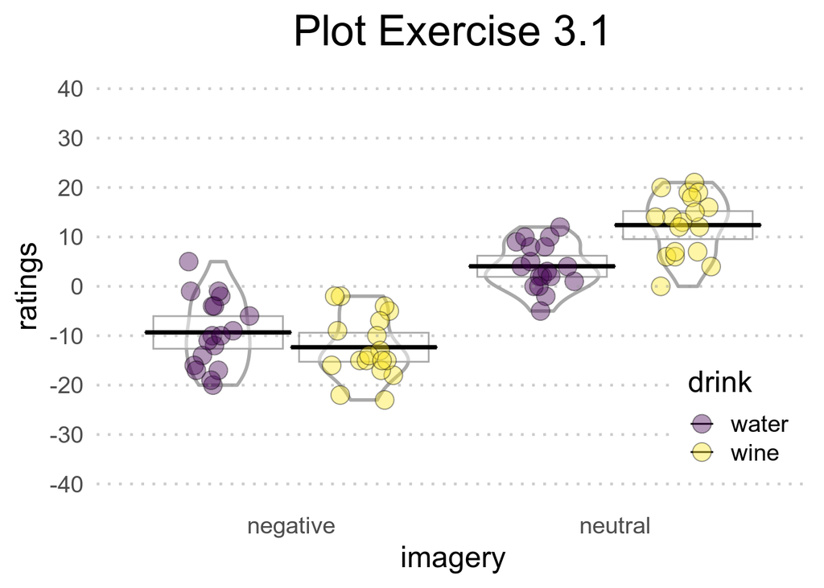

```r
library(viridis)
library(ggpirate)

RDIplot_ex_3_1 <-
  data_attitude_wine %>%
  ggplot(aes(
    x = imagery,
    y = ratings,
    color = drink,
    fill = drink
  )) +
  geom_pirate(
    bars = FALSE,
    cis = TRUE,
    lines = TRUE, lines_params = list(color = "black"),
    points = TRUE, points_params = list(shape = 21, color = "black", size = 5, alpha = .4),
    violins = TRUE, violins_params = list(size = 1),
    show.legend = TRUE
  ) +
  scale_y_continuous(
    limits = c(-100, 100),
    breaks = seq(-100, 100, 10)
  ) +
  coord_cartesian(ylim = c(-40, 40)) +
  geom_hline(
    yintercept = seq(-100, 100, 10),
    linetype = "dotted",
    colour = "#999999",
    size = .8,
    alpha = .5
  ) +
  scale_fill_viridis(
    option = "viridis",
    discrete = TRUE
  ) +
  ggtitle("Plot Exercise 3.1") +
  theme_minimal(base_size = 18) +
  theme(
    panel.grid = element_blank(),
    legend.box.background = element_rect(color = "transparent"),
    legend.position = c(.9, .2),
    plot.title = element_text(size = 26, hjust = .5)
  )

ggsave(
  filename = "plot_ex_3_1.png",
  plot = RDIplot_ex_3_1,
  path = here("doc/images"),
  width = 7, height = 7, units = "in",
  dpi = 600
)

RDIplot_ex_3_1
```

## Exercise 3.2

The same as above, separately for female and male participants.

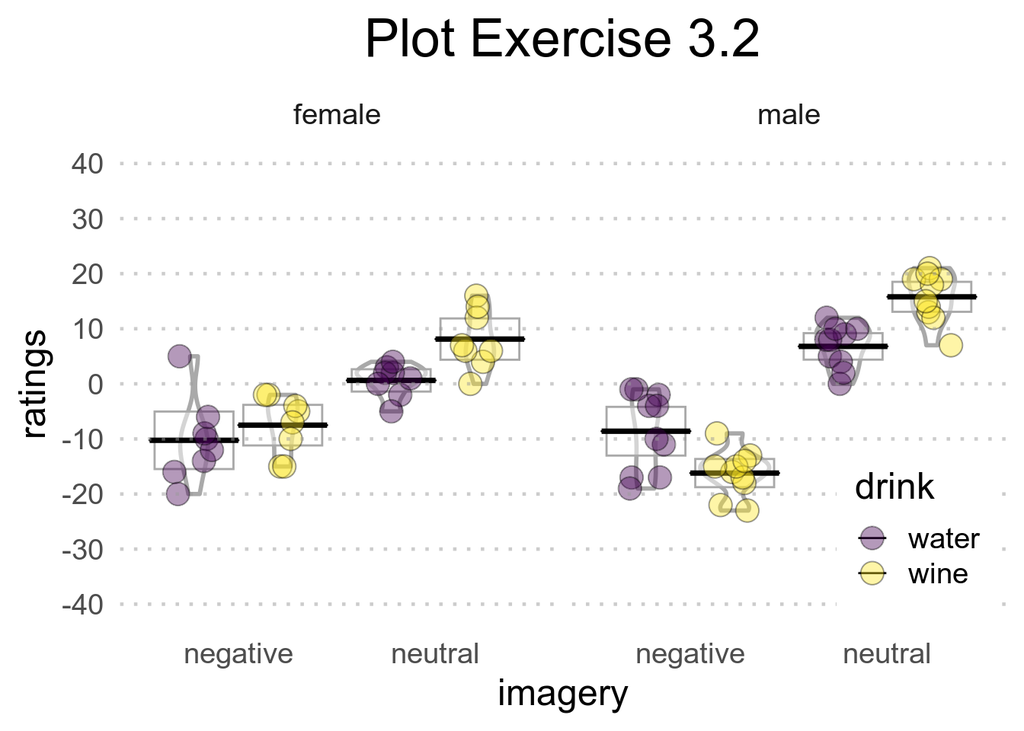

```r
RDIplot_ex_3_2 <-
  RDIplot_ex_3_1 +
  ggtitle("Plot Exercise 3.2") +
  facet_wrap(. ~ gender)

ggsave(
  filename = "plot_ex_3_2.png",
  plot = RDIplot_ex_3_2,
  path = here("doc/images"),
  width = 9, height = 7, units = "in",
  dpi = 600
)

RDIplot_ex_3_2
```

## Exercise 3 BONUS

Recreate a plot similar to #2 using the [`yarrr`](https://cran.r-project.org/web/packages/yarrr/vignettes/pirateplot.html) package.

```r
library(yarrr)

# following https://bookdown.org/ndphillips/YaRrr/saving-plots-to-a-file-with-pdf-jpeg-and-png.html
# this plot is saved as pdf to avoid 'Error in plot.new() : figure margins too large'
# displayed when using the functions 'png' or 'jpeg'
pdf(
  file = here("doc/images/plot_ex_3_bonus.pdf"), # directory + file name
  width = 9, # width (in inches)
  height = 7 # height (in inches)
)

pirateplot(
  formula = ratings ~ imagery + drink + gender, # dependent ~ independent variables
  data = data_attitude_wine, # data frame
  main = "Bonus Plot Exercise 3", # plot title
  ylim = c(-25, 25), # y-axis: axis limits
  ylab = "", # y-axis: no label
  inf.method = "ci", # type of inference: 95% confidence interval
  inf.within = participant, # ID variable
  # theme settings
  pal = "espresso", # color palette: see piratepal("all")
  point.o = .5, # data points: opacity (0-1)
  point.cex = 1.3, # data points: size
  inf.f.o = .3, # 95% CI box filling: opacity (0-1)
  bean.b.o = .6, # bean border: opacity (0-1)
  bean.f.o = .6, # bean filling: opacity (0-1)
  cap.beans = TRUE, # bean densities are capped at the data limits
  bty = "n", # no box around the plot
  gl.col = "gray", # background line color (major and minor lines)
  gl.lwd = 1, # background line width
  gl.lty = 2 # background line type (dashed)
)

dev.off()
```

[figure not shown]

## Exercise 4

### Exercise 4.1

Load `data_attitude_wine.csv`.

```r
data_attitude_wine <-
  read_csv(
    here(
      "tidy-data",
      "data_attitude_wine.csv"
    )
  )
```

#### Exercise 4.1.1

Run a 2 (**drink**) x 2 (**imagery**) repeated measures ANOVA on likeness ratings and display the results in console.

```r
library(afex)

rmANOVA_att_wine <- aov_ez(
  "participant",
  "ratings",
  data_attitude_wine,
  within = c("drink", "imagery"),
  type = 3
)

rmANOVA_att_wine
```

```
## Anova Table (Type 3 tests)
##
## Response: ratings
##          Effect    df   MSE          F ges p.value
## 1         drink 1, 17 27.68     4.62 * .05     .05
## 2       imagery 1, 17 57.32 114.03 *** .72  <.0001
## 3 drink:imagery 1, 17 28.85  20.03 *** .18   .0003
## ---
## Signif. codes:  0 '***' 0.001 '**' 0.01 '*' 0.05 '+' 0.1 ' ' 1
```

#### Exercise 4.1.2

Run paired contrasts and display the results in console.

```r
library(emmeans)

afex_options(emmeans_model = "multivariate")

posthoc_att_wine <-
  emmeans(rmANOVA_att_wine, ~ imagery * drink) %>%
  pairs(.,
    test = adjusted("free")
  ) %>%
  as.glht() %>%
  summary() %>%
  print()
```

```
##
##   Simultaneous Tests for General Linear Hypotheses
##
## Linear Hypotheses:
##                                     Estimate Std. Error t value Pr(>|t|)
## negative,wine - neutral,wine == 0    -24.722      2.531  -9.769   <1e-04 ***
## negative,wine - negative,water == 0   -3.000      2.102  -1.427    0.485
## negative,wine - neutral,water == 0   -16.389      2.205  -7.431   <1e-04 ***
## neutral,wine - negative,water == 0    21.722      2.140  10.150   <1e-04 ***
## neutral,wine - neutral,water == 0      8.333      1.365   6.106   <1e-04 ***
## negative,water - neutral,water == 0  -13.389      1.781  -7.519   <1e-04 ***
## ---
## Signif. codes:  0 '***' 0.001 '**' 0.01 '*' 0.05 '.' 0.1 ' ' 1
## (Adjusted p values reported -- single-step method)
```

#### Exercise 4.1.3

Run bootstrapped effect sizes (calculate **Pearson’s *r*** instead of Hegdes’ *g*) and display the results in console.

```r
att_wine_prep_bootES <-
  data_attitude_wine %>%
  pivot_wider(
    id_cols = c("participant", "gender"),
    names_from = c("drink", "imagery"),
    values_from = "ratings",
    names_sep = "_"
  ) %>%
  mutate(
    wine_negativeVSwine_neutral = wine_negative - wine_neutral,
    wine_negativeVSwater_negative = wine_negative - water_negative,
    wine_negativeVSwater_neutral = wine_negative - water_neutral,
    wine_neutralVSwater_negative = wine_neutral - water_negative,
    wine_neutralVSwater_neutral = wine_neutral - water_neutral,
    water_negativeVSwater_neutral = water_negative - water_neutral
  ) %>%
  dplyr::select(-c(wine_negative:water_neutral)) %>%
  pivot_longer(
    cols = wine_negativeVSwine_neutral:water_negativeVSwater_neutral,
    names_to = "diff_conds",
    values_to = "ratings"
  )

library(bootES)

set.seed(20200115)

att_wine_bootES <-
  att_wine_prep_bootES %>%
  group_by(diff_conds) %>%
  nest() %>%
  rename(diff_ratings = data) %>%
  mutate(
    bootstrap = map(
      diff_ratings,
      ~ bootES(
        .,
        data.col = "ratings",
        R = 5000,
        effect.type = "r",
        ci.type = "bca",
        ci.conf = .95
      ),
      data = .
    ),
    tidy = map(bootstrap, broom::tidy, conf.int = TRUE)
  ) %>%
  ungroup()

att_wine_Pearson <-
  att_wine_bootES %>%
  unnest(tidy) %>%
  dplyr::select(
    diff_conds,
    "Pearson_r" = statistic,
    "CI95_low" = conf.low,
    "CI95_high" = conf.high,
    bias,
    "std_error" = std.error
  ) %>%
  print()
```

```
## # A tibble: 6 x 6
##   diff_conds                    Pearson_r CI95_low CI95_high      bias std_error
##   <chr>                             <dbl>    <dbl>     <dbl>     <dbl>     <dbl>
## 1 wine_negativeVSwine_neutral      -0.921   -0.971    -0.864 -0.00127     0.0274
## 2 wine_negativeVSwater_negative    -0.327   -0.718     0.121 -0.00682     0.219
## 3 wine_negativeVSwater_neutral     -0.874   -0.951    -0.774 -0.000277    0.0457
## 4 wine_neutralVSwater_negative      0.926    0.868     0.969  0.00232     0.0265
## 5 wine_neutralVSwater_neutral       0.829    0.705     0.924  0.00226     0.0561
## 6 water_negativeVSwater_neutral    -0.877   -0.972    -0.708 -0.000481    0.0761
```

### Exercise 4.2

#### Exercise 4.2.1

Run a 2 (**gender**) x 2 (**drink**) x 2 (**imagery**) mixed ANOVA on likeness ratings. **Remember**: `gender` is a between-subject factor!

```r
rmANOVA_att_wine_gender <- aov_ez(
  "participant",
  "ratings",
  data_attitude_wine,
  within = c("drink", "imagery"),
  between = "gender",
  type = 3
)

rmANOVA_att_wine_gender
```

```
## Anova Table (Type 3 tests)
##
## Response: ratings
##                 Effect    df   MSE          F ges p.value
## 1               gender 1, 16 35.90       1.43 .03     .25
## 2                drink 1, 16 23.97     6.29 * .08     .02
## 3         gender:drink 1, 16 23.97     3.63 + .05     .07
## 4              imagery 1, 16 30.57 198.50 *** .77  <.0001
## 5       gender:imagery 1, 16 30.57   15.88 ** .21    .001
## 6        drink:imagery 1, 16 20.90  24.23 *** .22   .0002
## 7 gender:drink:imagery 1, 16 20.90     7.46 * .08     .01
## ---
## Signif. codes:  0 '***' 0.001 '**' 0.01 '*' 0.05 '+' 0.1 ' ' 1
```

#### Exercise 4.2.2

Paired contrasts: test **only** difference ratings between *female* and *male* participants (**hint**: see example [here](https://cran.r-project.org/web/packages/afex/vignettes/afex_anova_example.html#post-hoc-contrasts-and-plotting)).

```r
posthoc_att_wine_gender <-
  emmeans(rmANOVA_att_wine_gender, ~ gender | imagery | drink) %>%
  pairs(.,
    test = adjusted("free")
  ) %>%
  as.glht() %>%
  summary() %>%
  print()
```

```
## $`imagery = negative, drink = wine`
##
##   Simultaneous Tests for General Linear Hypotheses
##
## Linear Hypotheses:
##                    Estimate Std. Error t value Pr(>|t|)
## female - male == 0    8.700      2.224   3.913  0.00124 **
## ---
## Signif. codes:  0 '***' 0.001 '**' 0.01 '*' 0.05 '.' 0.1 ' ' 1
## (Adjusted p values reported -- single-step method)
##
##
## $`imagery = neutral, drink = wine`
##
##   Simultaneous Tests for General Linear Hypotheses
##
## Linear Hypotheses:
##                    Estimate Std. Error t value Pr(>|t|)
## female - male == 0   -7.675      2.307  -3.327  0.00427 **
## ---
## Signif. codes:  0 '***' 0.001 '**' 0.01 '*' 0.05 '.' 0.1 ' ' 1
## (Adjusted p values reported -- single-step method)
##
##
## $`imagery = negative, drink = water`
##
##   Simultaneous Tests for General Linear Hypotheses
##
## Linear Hypotheses:
##                    Estimate Std. Error t value Pr(>|t|)
## female - male == 0   -1.650      3.469  -0.476    0.641
## (Adjusted p values reported -- single-step method)
##
##
## $`imagery = neutral, drink = water`
##
##   Simultaneous Tests for General Linear Hypotheses
##
## Linear Hypotheses:
##                    Estimate Std. Error t value Pr(>|t|)
## female - male == 0   -6.175      1.658  -3.724  0.00184 **
## ---
## Signif. codes:  0 '***' 0.001 '**' 0.01 '*' 0.05 '.' 0.1 ' ' 1
## (Adjusted p values reported -- single-step method)
```

#### Exercise 4.2.3

Bootstrapped effect sizes (**Cohen’s *d***) of the paired comparisons above.

```r
att_wine_gender_prep_bootES <-
  data_attitude_wine %>%
  unite(condition, c(drink, imagery), sep = "_", remove = TRUE)

att_wine_gender_bootES <-
  att_wine_gender_prep_bootES %>%
  group_by(condition) %>%
  nest() %>%
  rename(all_ratings = data) %>%
  mutate(
    bootstrap = map(
      all_ratings,
      ~ bootES(
        .,
        data.col = "ratings",
        group.col = "gender",
        contrast = c("female", "male"),
        R = 5000,
        effect.type = "cohens.d",
        ci.type = "bca",
        ci.conf = .95
      ),
      data = .
    ),
    tidy = map(bootstrap, broom::tidy, conf.int = TRUE)
  ) %>%
  ungroup()

att_wine_gender_Cohen <-
  att_wine_gender_bootES %>%
  unnest(tidy) %>%
  dplyr::select(
    condition,
    "Cohen_d" = statistic,
    "CI95_low" = conf.low,
    "CI95_high" = conf.high,
    bias,
    "std_error" = std.error
  ) %>%
  print()
```

```
## # A tibble: 4 x 6
##   condition      Cohen_d CI95_low CI95_high    bias std_error
##   <chr>            <dbl>    <dbl>     <dbl>   <dbl>     <dbl>
## 1 wine_negative   -1.86    -3.71     -0.946 -0.190      0.708
## 2 wine_neutral     1.58     0.712     3.30   0.178      0.669
## 3 water_negative   0.226   -0.685     1.47   0.0642     0.539
## 4 water_neutral    1.77     0.943     3.47   0.180      0.645
```

[Antonio Schettino](https://asch3tti.netlify.com/)

*schettino@eur.nl*